# R 語言特訓班 4：關聯資料庫與資料整合

黃大維，臺灣大學統計碩士

2018 年 8 月 1 日

## 4-1：關聯資料庫 (Relational Database) 簡介

儘管串流資料的出現以及分散式計算與儲存的需求，使得非關聯資料庫變得越來越普遍，但目前最常見的資料庫形式仍然是「關聯資料庫」，因此 R 的 tidy 架構其實也是關聯資料庫的基礎上建立而成。 Tidy 的定義其實可以完全對應到「關聯模型」 (relational model)：

- Tidy 中的變數 (variale) / column $\Rightarrow$ 關聯模型中稱為 Attribute
- Tidy 中的個體 (observation) / row $\Rightarrow$ 關聯模型中稱為 Tuple
- Tidy 中的觀察物件形成的 table $\Rightarrow$ 關聯模型中稱為 Relation

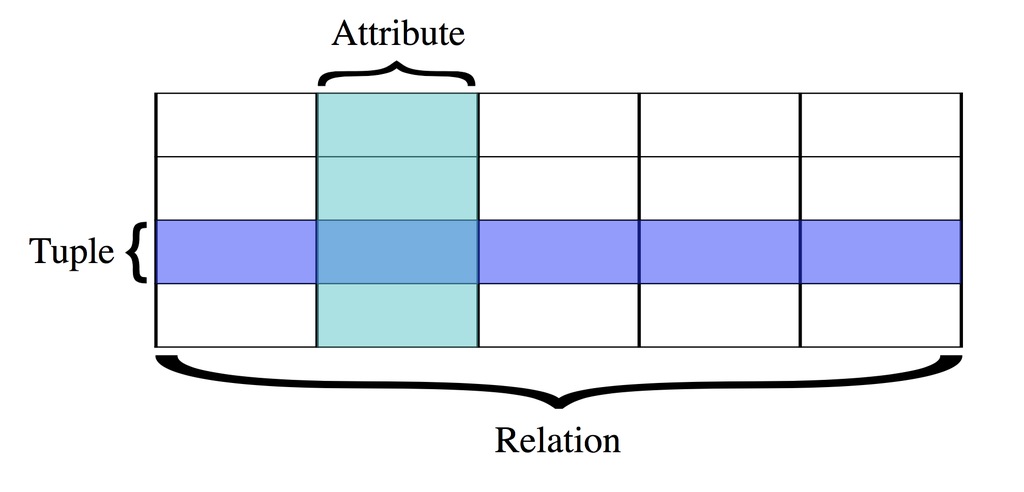

當我們要串連多個上述的資料表 / relation 時要怎麼辦呢？我們會利用「鍵」(key) 來串連不同的資料表，一般來說有兩種重要的連結鍵：

- 主鍵 (Primary Key)：用來辨識 tuple 的欄位, 一個 tuple 只能有一個 primary key value，而且 primary key values 不能重複。
- 連外鍵 (Foreign Key)：用來連結其他資料表主鍵之用的連結鍵。

通常我們會喜歡用編號 / ID 來作為主鍵，但其實也可以挑選其他欄位作為主鍵。在連結時，我們較常將兩個資料表的主鍵做連結，或是一個資料表的主鍵與另一資料表的連外鍵。

### 案例：線上連續劇觀看資料

假設我們在線上戲劇觀看平台公司工作，我們最重要的資料集合有三個：

- `watch.table`：使用者的觀看內容與行為紀錄
- `user.table`：使用者的個人資料
- `drame.table`：戲劇的相關資料

以下是這次案例的模擬資料集合。

```r
library(tidyverse)
watch.table <- read_csv("watch_table.csv")
watch.table
```

```
## # A tibble: 39 x 5
##    watch_id time_stamp     user_id drama_id device
##    <chr>    <chr>          <chr>   <chr>    <chr>
##  1 W0000001 2018/6/1 15:30 U0001   D00004   iOS
##  2 W0000036 2018/6/1 16:30 U0015   D00005   Chrome
##  3 W0000002 2018/6/1 17:28 U0001   D00004   iOS
##  4 W0000035 2018/6/1 18:28 U0013   D00002   iOS
##  5 W0000020 2018/6/1 20:19 U0006   D00005   iOS
##  6 W0000003 2018/6/1 22:12 U0001   D00004   iOS
##  7 W0000037 2018/6/1 23:01 U0015   D00005   Chrome
##  8 W0000004 2018/6/2 0:51  U0002   D00003   Android
##  9 W0000005 2018/6/2 1:08  U0002   D00003   Android
## 10 W0000006 2018/6/2 1:48  U0002   D00003   Android
## # ... with 29 more rows
```

```r
user.table <- read_csv("user_table.csv")
user.table
```

```
## # A tibble: 15 x 6
##    user_id user_name    gender   age location  payment
##    <chr>   <chr>        <chr>  <int> <chr>       <int>
##  1 U0001   David Huang  male      24 Taipei          1
##  2 U0002   His Shen     male      25 Taipei          0
##  3 U0003   Julie Sung   female    37 Hsinchu         0
##  4 U0004   James Hsieh  male      29 Taipei          0
##  5 U0005   Jane Lin     female    18 Miaoli          1
##  6 U0006   Lobelia Wang female    42 Tainan          1
##  7 U0007   Cindy Kao    female    19 Kaohsiung       0
##  8 U0008   Lucas Yang   male      29 Taipei          0
##  9 U0009   Jason Chen   male      26 Taipei          0
## 10 U0010   Celine Lee   female    25 Yunlin          0
## 11 U0011   Jean Ding    female    28 Tainan          0
## 12 U0012   Eileen Liu   female    33 Kaohsiung       1
## 13 U0013   Joy Chiu     female    36 Taipei          1
## 14 U0014   Ashley Kuo   female    45 Taipei          1
## 15 U0015   Yiwen Yu     male      37 Hsinchu         0
```

```r
drame.table <- read_csv("drama_table.csv")
drame.table
```

```
## # A tibble: 7 x 5
##   drama_id drama_name             area   actors   description
##   <chr>    <chr>                  <chr>  <chr>    <chr>
## 1 D00001   Descendants Of The Sun Korea  "{\"act… "{\"description\": \"De…
## 2 D00002   Bromance               Taiwan "{\"act… "{\"description\": \"Br…
## 3 D00003   From 5 to 9            Japan  "{\"act… "{\"description\": \"Fr…
## 4 D00004   The Flame's Daughter   China  "{\"act… "{\"description\": \"Ba…
## 5 D00005   House of Cards         US     "{\"act… "{\"description\": \"Ho…
## 6 D00006   She was Pretty         Korea  "{\"act… "{\"description\": \"Wh…
## 7 D00007   I Should Not Love You  Taiwan "{\"act… "{\"description\": \"Wh…
```

上述三個資料集合，其實是透過下列方式相互連結的：

- `watch.table`：主鍵為 `watch_id`，連外鍵為 `user_id` 與 `drama_id`
- `user.table`：主鍵為 `user_id`，無連外鍵
- `drame.table`：主鍵為 `drama_id`，無連外鍵

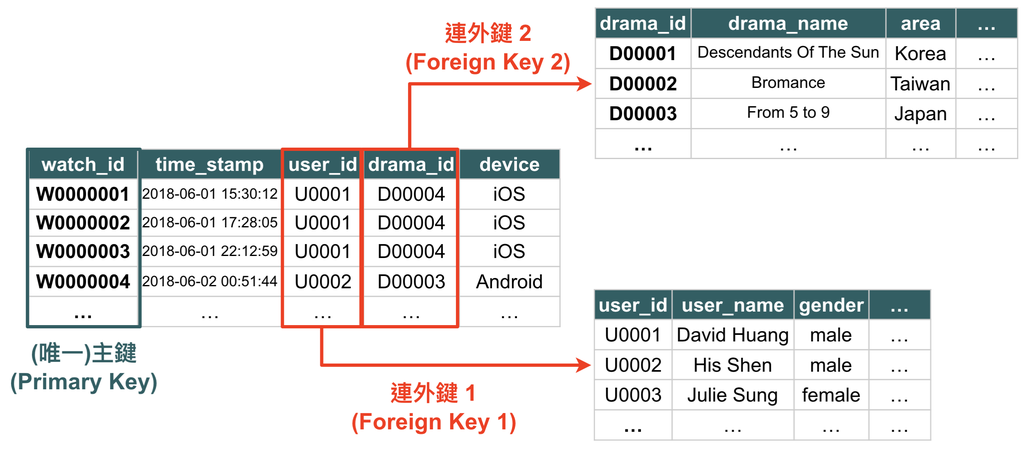

## 4-2：合併資料集合並增加新變數

如果想要將上述案例中的三個表格總合成一張大表，在 R 中可以利用各類的 `join` 指令幫你完成任務。 Tidy 架構中連結兩張表的方式主要有以下兩種：

- mutating join：將兩張表結合，並在新的表格中納入兩張表格有的變數
- filtering join：透過另一張表的資訊篩選目標資料表格的 rows

在這裡我們主要先介紹 mutating join：將兩張表結合並納入新變數。在此處我們先使用比較簡單的資料集合讓你了解各種 joins 的運作方式：

```r
table.A <- tribble(
  ~key, ~val_A,
  1, "a_val_1",
  2, "a_val_2",
  3, "a_val_3",
  4, "a_val_4"
)

table.B <- tribble(
  ~key, ~val_B,
  1, "b_val_1",
  2, "b_val_2",
  5, "b_val_5"
)
```

### 1. Inner Join 與 Full Join

Inner join 會取兩個資料集合交集的個體進行合併，如下圖所示。

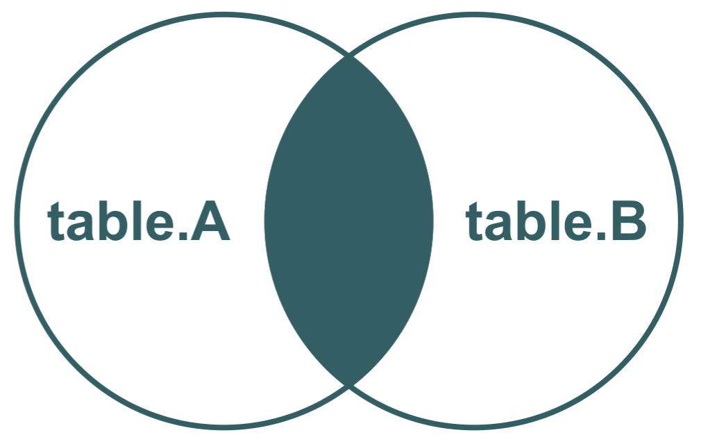

在 R 語言中可以透過 `table.A %>% inner_join(table.B)` 完成。

- 比對 `table.A` 中 rows 的鍵是否出現在 `table.B` 的鍵中
- 如果該 row 的鍵有出現在 `table.B` 的鍵中，則合併該 row 與 `table.B` 被比對的 row
- 如果沒有出現，則不納入新的資料集合

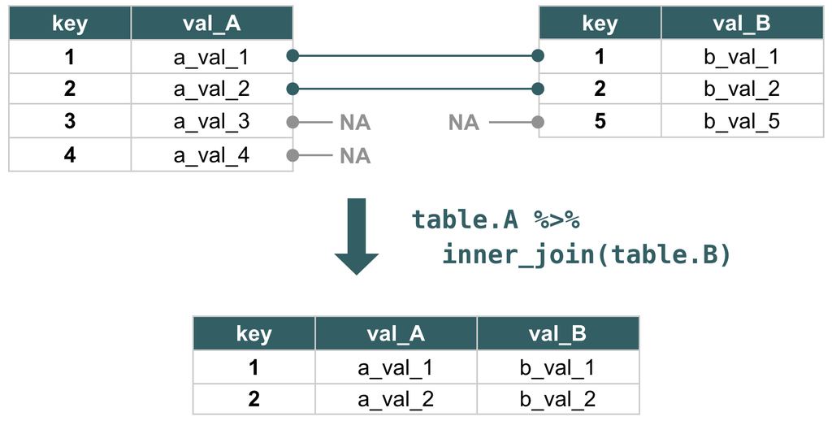

R 語言執行的結果如下：

```r
table.A %>%
  inner_join(table.B)
```

```
## # A tibble: 2 x 3
##     key val_A   val_B
##   <dbl> <chr>   <chr>
## 1     1 a_val_1 b_val_1
## 2     2 a_val_2 b_val_2
```

Full join 則會取兩個資料集合的聯集進行合併，如下圖所示。

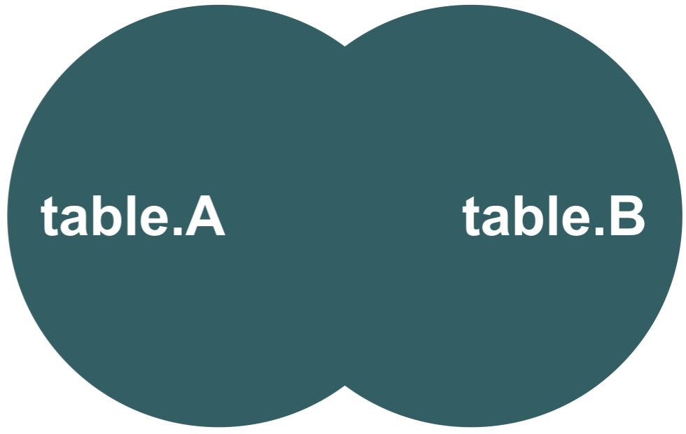

在 R 語言中可以透過 `table.A %>% full_join(table.B)` 完成，原理如下圖所示：

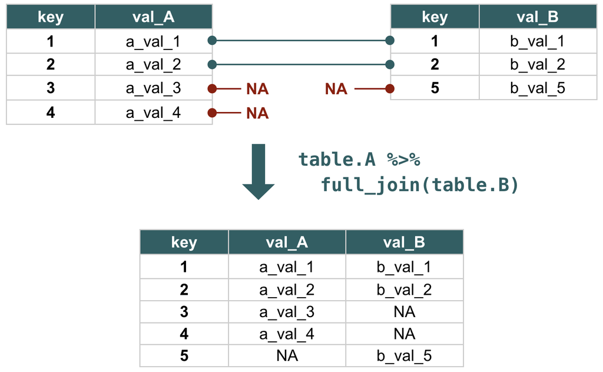

R 語言執行的結果如下：

```r
table.A %>%
  full_join(table.B)
```

```
## # A tibble: 5 x 3
##     key val_A   val_B
##   <dbl> <chr>   <chr>
## 1     1 a_val_1 b_val_1
## 2     2 a_val_2 b_val_2
## 3     3 a_val_3 <NA>
## 4     4 a_val_4 <NA>
## 5     5 <NA>    b_val_5
```

### 2. Left Join 與 Right Join

Left join 會將 A 集合中的所有個體與 B 集合的變數合併，如下圖所示。

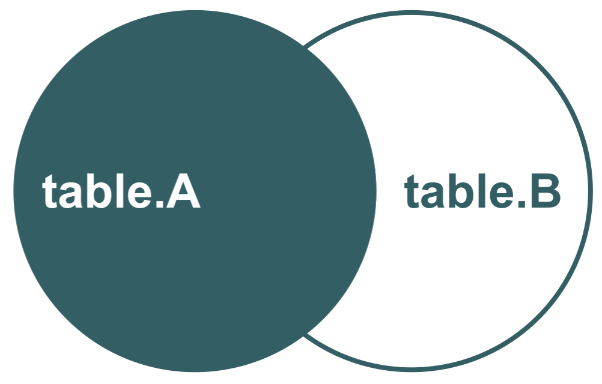

在 R 語言中可以透過 `table.A %>% left_join(table.B)` 完成，原理如下圖所示：

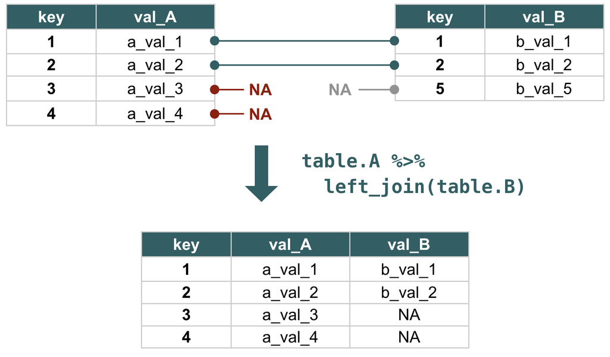

R 語言執行的結果如下：

```r
table.A %>%
  left_join(table.B)
```

```
## # A tibble: 4 x 3
##     key val_A   val_B
##   <dbl> <chr>   <chr>
## 1     1 a_val_1 b_val_1
## 2     2 a_val_2 b_val_2
## 3     3 a_val_3 <NA>
## 4     4 a_val_4 <NA>
```

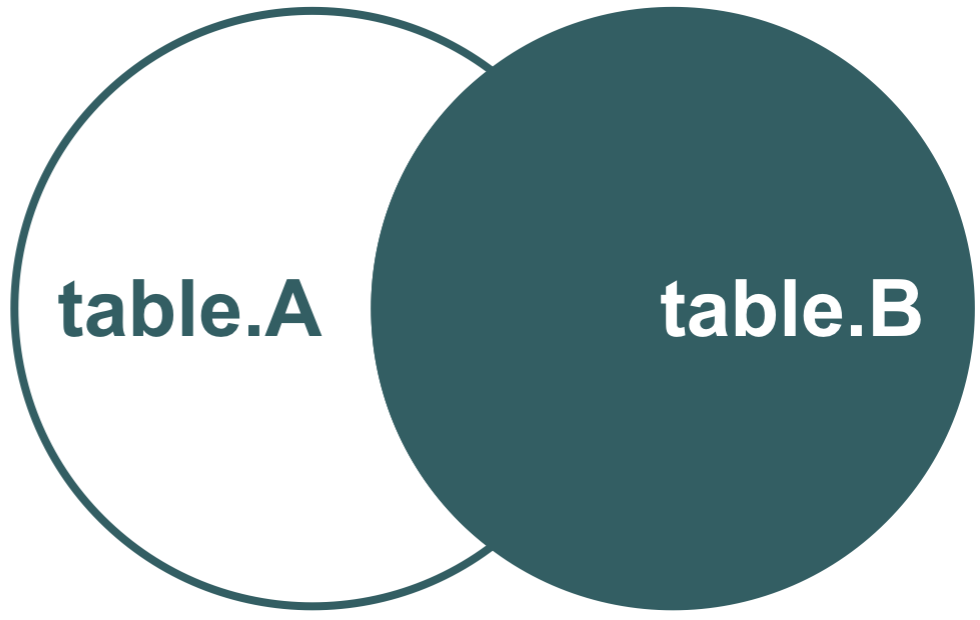

在 R 語言中可以透過 `table.A %>% right_join(table.B)` 完成，原理如下圖所示：

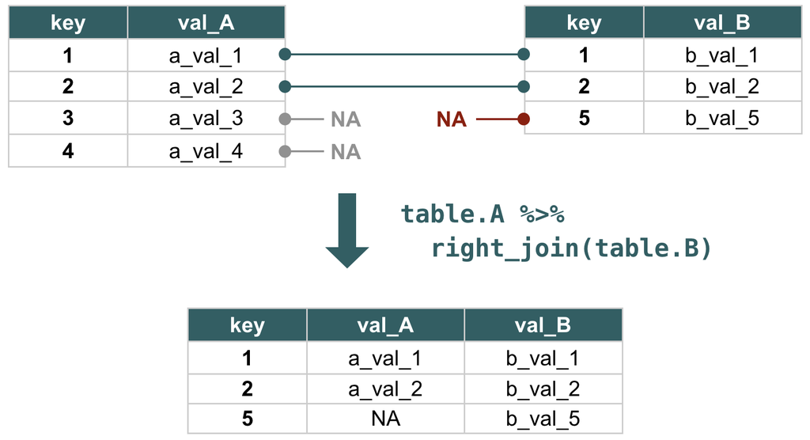

R 語言執行的結果如下：

```r
table.A %>%
  right_join(table.B)
```

```
## # A tibble: 3 x 3
##     key val_A   val_B
##   <dbl> <chr>   <chr>
## 1     1 a_val_1 b_val_1
## 2     2 a_val_2 b_val_2
## 3     5 <NA>    b_val_5
```

### 3. 多重鍵值的資料表進行合併

在關聯資料庫簡介中，一個資料表主鍵的鍵值是唯一不重複的，但連外鍵可能會重複。因此，將 `table.A` 與 `table.B` 合併時，可能會遇到以下狀況：

- 只有一張資料表有重複鍵值：  
  這種情況很常出現在「`table.A` 的連外鍵與 `table.B` 的主鍵」作為合併依據。比如說：想將 `watch.table` 與 `user.table` 依照 `user_id` 做合併，對於 `watch.table` 而言就會出現多重鍵值的情形。
- 兩張資料表有重複鍵值：  
  這種情況很少發生，通常我們不會將兩個資料表針對他們的連外鍵合併，如果發生了代表 (1) 需要重新思考如何合併資料表 (2) 資料表可能有問題，出現了重複主鍵的情況。

#### 只有一張資料表有重複鍵值

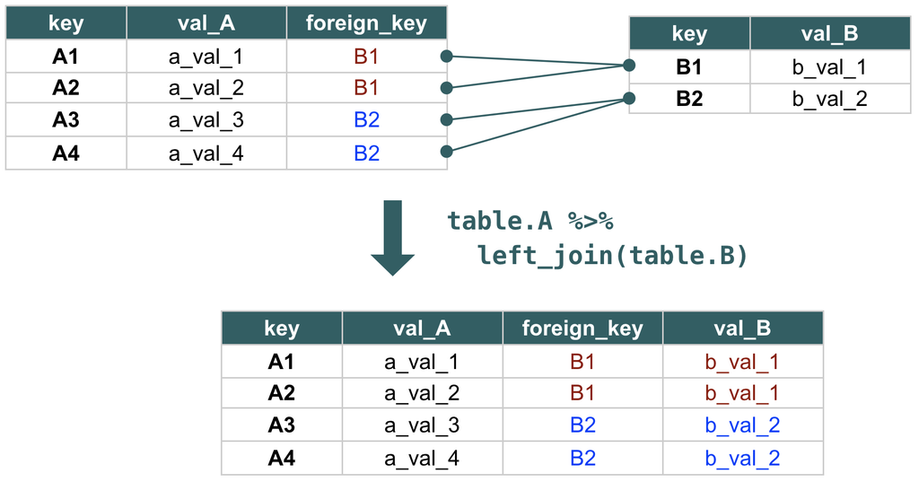

R 語言運作的結果如下：

```r
table.A <- tribble(
  ~key, ~val_A, ~foreign_key,
  "A1", "a_val_1", "B1",
  "A2", "a_val_2", "B1",
  "A3", "a_val_3", "B2",
  "A4", "a_val_4", "B2"
)

table.B <- tribble(
  ~key, ~val_B,
  "B1", "b_val_1",
  "B2", "bb_val_2"
)

table.A %>%
  left_join(table.B, by = c("foreign_key" = "key"))
```

```
## # A tibble: 4 x 4
##   key   val_A   foreign_key val_B
##   <chr> <chr>   <chr>       <chr>
## 1 A1    a_val_1 B1          b_val_1
## 2 A2    a_val_2 B1          b_val_1
## 3 A3    a_val_3 B2          bb_val_2
## 4 A4    a_val_4 B2          bb_val_2
```

#### 兩張資料表有重複鍵值

如果遇到兩張資料表都有重複鍵值的話，會如下圖的機制進行合併：

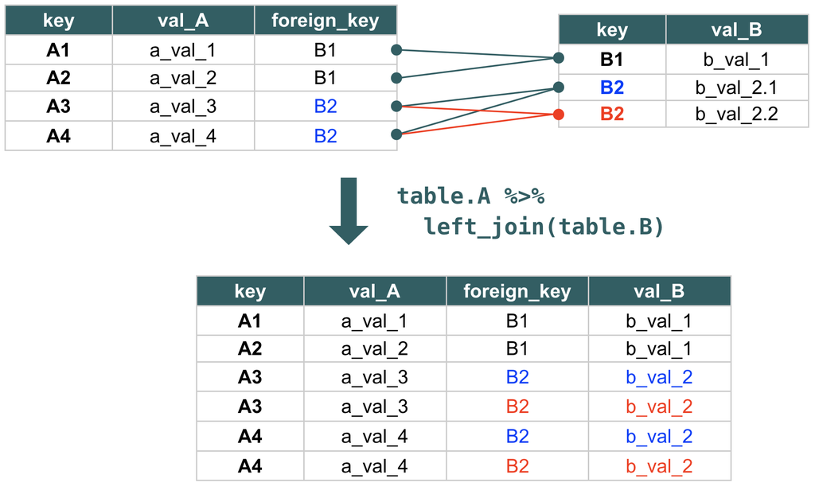

R 語言運作的結果如下：

```r
table.A <- tribble(
  ~key, ~val_A, ~foreign_key,
  "A1", "a_val_1", "B1",
  "A2", "a_val_2", "B1",
  "A3", "a_val_3", "B2",
  "A4", "a_val_4", "B2"
)

table.B <- tribble(
  ~key, ~val_B,
  "B1", "b_val_1",
  "B2", "bb_val_2.1",
  "B2", "bb_val_2.2"
)

table.A %>%
  left_join(table.B, by = c("foreign_key" = "key"))
```

```
## # A tibble: 6 x 4
##   key   val_A   foreign_key val_B
##   <chr> <chr>   <chr>       <chr>
## 1 A1    a_val_1 B1          b_val_1
## 2 A2    a_val_2 B1          b_val_1
## 3 A3    a_val_3 B2          bb_val_2.1
## 4 A3    a_val_3 B2          bb_val_2.2
## 5 A4    a_val_4 B2          bb_val_2.1
## 6 A4    a_val_4 B2          bb_val_2.2
```

### 4. 個案練習

有了上述指令，我們就知道如何將 `watch.table` 與其他兩個報表合併了！

```r
full.table <- watch.table %>%
  left_join(
    user.table,
    by = "user_id"
  ) %>%
  left_join(
    drame.table,
    by = "drama_id"
  )

print(full.table)
```

```
## # A tibble: 39 x 14
##    watch_id time_stamp    user_id drama_id device  user_name  gender   age
##    <chr>    <chr>         <chr>   <chr>    <chr>   <chr>      <chr>  <int>
##  1 W0000001 2018/6/1 15:… U0001   D00004   iOS     David Hua… male      24
##  2 W0000036 2018/6/1 16:… U0015   D00005   Chrome  Yiwen Yu   male      37
##  3 W0000002 2018/6/1 17:… U0001   D00004   iOS     David Hua… male      24
##  4 W0000035 2018/6/1 18:… U0013   D00002   iOS     Joy Chiu   female    36
##  5 W0000020 2018/6/1 20:… U0006   D00005   iOS     Lobelia W… female    42
##  6 W0000003 2018/6/1 22:… U0001   D00004   iOS     David Hua… male      24
##  7 W0000037 2018/6/1 23:… U0015   D00005   Chrome  Yiwen Yu   male      37
##  8 W0000004 2018/6/2 0:51 U0002   D00003   Android His Shen   male      25
##  9 W0000005 2018/6/2 1:08 U0002   D00003   Android His Shen   male      25
## 10 W0000006 2018/6/2 1:48 U0002   D00003   Android His Shen   male      25
## # ... with 29 more rows, and 6 more variables: location <chr>,
## #   payment <int>, drama_name <chr>, area <chr>, actors <chr>,
## #   description <chr>
```

有了整張表格之後，我們就可以計算一些加總報表，比如說：

1. 每部劇男性/女性的觀看次數

```r
full.table %>%
  group_by(drama_id, gender) %>%
  summarize(view_count = length(watch_id))
```

```
## # A tibble: 13 x 3
## # Groups:   drama_id [?]
##    drama_id gender view_count
##    <chr>    <chr>       <int>
##  1 D00001   female          3
##  2 D00001   male            5
##  3 D00002   female          1
##  4 D00002   male            2
##  5 D00003   female          1
##  6 D00003   male            5
##  7 D00004   female          4
##  8 D00004   male            3
##  9 D00005   female          3
## 10 D00005   male            4
## 11 D00006   female          4
## 12 D00006   male            1
## 13 D00007   female          3
```

2. 每部劇男性/女性的觀看人數

```r
full.table %>%
  group_by(drama_id, gender) %>%
  summarize(user_count = length(unique(user_id)))
```

```
## # A tibble: 13 x 3
## # Groups:   drama_id [?]
##    drama_id gender user_count
##    <chr>    <chr>       <int>
##  1 D00001   female          2
##  2 D00001   male            2
##  3 D00002   female          1
##  4 D00002   male            2
##  5 D00003   female          1
##  6 D00003   male            1
##  7 D00004   female          1
##  8 D00004   male            1
##  9 D00005   female          2
## 10 D00005   male            1
## 11 D00006   female          3
## 12 D00006   male            1
## 13 D00007   female          2
```

## 4-3：透過其他資料表篩選個體

在 `dplyr` 中還有一種 join 的方式，不是將 `table.B` 的變數納入新資料表中，而是篩選出比對到的個體，其中：

- `semi_join`：`table.A` 篩選出有出現在 `table.B` 的個體
- `anti_join`：`table.A` 篩選出沒出現在 `table.B` 的個體

儘管上述這項功能可以被 `filter` 函數完成，但如果同時要比對多個資料表的多個欄位時，用 filtering join 會比較好。

```r
# Easy
user.table %>%
  semi_join(watch.table, by = "user_id")
```

```
## # A tibble: 13 x 6
##    user_id user_name    gender   age location  payment
##    <chr>   <chr>        <chr>  <int> <chr>       <int>
##  1 U0001   David Huang  male      24 Taipei          1
##  2 U0002   His Shen     male      25 Taipei          0
##  3 U0003   Julie Sung   female    37 Hsinchu         0
##  4 U0004   James Hsieh  male      29 Taipei          0
##  5 U0005   Jane Lin     female    18 Miaoli          1
##  6 U0006   Lobelia Wang female    42 Tainan          1
##  7 U0008   Lucas Yang   male      29 Taipei          0
##  8 U0009   Jason Chen   male      26 Taipei          0
##  9 U0010   Celine Lee   female    25 Yunlin          0
## 10 U0011   Jean Ding    female    28 Tainan          0
## 11 U0012   Eileen Liu   female    33 Kaohsiung       1
## 12 U0013   Joy Chiu     female    36 Taipei          1
## 13 U0015   Yiwen Yu     male      37 Hsinchu         0
```

```r
# Hard-to-read code
user.table %>%
  filter(user_id %in% watch.table$user_id)
```

```
## # A tibble: 13 x 6
##    user_id user_name    gender   age location  payment
##    <chr>   <chr>        <chr>  <int> <chr>       <int>
##  1 U0001   David Huang  male      24 Taipei          1
##  2 U0002   His Shen     male      25 Taipei          0
##  3 U0003   Julie Sung   female    37 Hsinchu         0
##  4 U0004   James Hsieh  male      29 Taipei          0
##  5 U0005   Jane Lin     female    18 Miaoli          1
##  6 U0006   Lobelia Wang female    42 Tainan          1
##  7 U0008   Lucas Yang   male      29 Taipei          0
##  8 U0009   Jason Chen   male      26 Taipei          0
##  9 U0010   Celine Lee   female    25 Yunlin          0
## 10 U0011   Jean Ding    female    28 Tainan          0
## 11 U0012   Eileen Liu   female    33 Kaohsiung       1
## 12 U0013   Joy Chiu     female    36 Taipei          1
## 13 U0015   Yiwen Yu     male      37 Hsinchu         0
```

```r
# Filter non-matched observationn
user.table %>%
  anti_join(watch.table, by = "user_id")
```

```
## # A tibble: 2 x 6
##   user_id user_name  gender   age location  payment
##   <chr>   <chr>      <chr>  <int> <chr>       <int>
## 1 U0007   Cindy Kao  female    19 Kaohsiung       0
## 2 U0014   Ashley Kuo female    45 Taipei          1
```

## 4-4：集合運算

最後這項功能並不常用。前面的 `semi_join` 與 `anti_join` 是比對 `table.A` 與 `table.B` 的鍵值，而此處介紹的功能則是比對 `table.A` 的整個 row 是否有出現 `table.B` 之中。

- `intersect(x, y)`：回傳同時出現在 `x` 與 `y` 的觀察個體
- `union(x, y)`：回傳有出現在 `x` 或 `y` 的觀察個體，且個體 / row 不會重複
- `setdiff(x, y)`: 回傳有出現在 `x` 但沒有出現在 `y` 的觀察個體

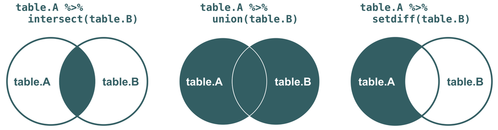

```r
table.A <- tribble(
  ~var_1, ~var_2,
  "1-1", "1-2",
  "2-1", "2-2",
  "3-1", "3-2-A"
)

table.B <- tribble(
  ~var_1, ~var_2,
  "1-1", "1-2",
  "2-1", "2-2",
  "3-1", "3-2-B",
  "5-1", "5-2"
)

table.A %>% intersect(table.B)
```

```
## # A tibble: 2 x 2
##   var_1 var_2
##   <chr> <chr>
## 1 1-1   1-2
## 2 2-1   2-2
```

```r
table.A %>% union(table.B)
```

```
## # A tibble: 5 x 2
##   var_1 var_2
##   <chr> <chr>
## 1 5-1   5-2
## 2 3-1   3-2-B
## 3 3-1   3-2-A
## 4 2-1   2-2
## 5 1-1   1-2
```

```r
table.A %>% setdiff(table.B)
```

```
## # A tibble: 1 x 2
##   var_1 var_2
##   <chr> <chr>
## 1 3-1   3-2-A
```

```r
table.B %>% setdiff(table.A)
```

```
## # A tibble: 2 x 2
##   var_1 var_2
##   <chr> <chr>
## 1 3-1   3-2-B
## 2 5-1   5-2
```